# A Seamless Integration of Gretl and R

Sagiru Mati (PhD)

# 1 About gretlR

gretlR is an R package that can run `gretl` program from R Markdown.

# 2 Installation

gretlR can be installed using the following commands in R.

```r
install.packages("gretlR")

          OR

devtools::install_github('sagirumati/gretlR')
```

# 3 Usage

Please load the gretlR package as follows:

````
```{r gretlR}
library(gretlR)
```
````

Then create a chunk for `gretl` as shown below:

````
```{gretl gretlR,eval=T,echo=T,comment=NULL}
nulldata 500
set seed 13
gretl1 = normal()
gretl2 = normal()
setobs 12 1980:01 --time-series
gnuplot gretl1 --time-series --with-lines --output="line.png"
gnuplot gretl2 gretl1 --output="scatter.png"
ols gretl1 const gretl2
modeltab add
tabprint --output="olsTable.Rmd"
tabprint --output="olsTable.tex"
tabprint --output="olsTable.csv"
eqnprint --output="olsEquation.tex"
```
````

The above chunk creates a gretl program with the chunk’s content, then automatically run the gretl script, which will save gretl outputs in the new folder `gretlR` created in the current working directory.

# 4 include_graph function

We can *dynamically and reproducibly* fetch the `gretl` graph object we created with the `gretl` chunk using the following R chunk:

For the scatter graph:

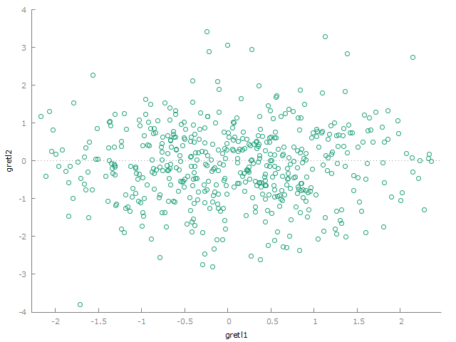

Figure 4.1: Scatter graph produced by gretl chunk

```r
include_graph(chunk = "gretlR",graph = "scatter.png")
```

or the line graph:

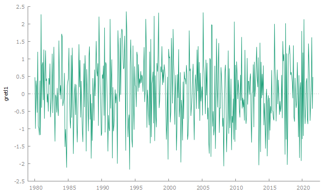

Figure 4.2: Line graph produced by gretl chunk

```r
include_graph(chunk = "gretlR",graph = "line.png")
```

# 5 include_tex function

we can also include the equation of the OLS generated by the `gretl` chunk and save as `olsEquation.tex`.

If the output is `pdf`, one can use the raw `LaTeX` codes as follows:

`\input{gretlR/gretlR/olsEquation.tex}`

Or use `include_tex` function to include the equation as shown below:

```r
include_tex(chunk = "gretlR",tex = "olsEquation")
```

[output not shown]

```r
include_tex(chunk = "gretlR",tex = "olsTable",start = 7,end = 24)
```

[output not shown]

The OLS table output is saved by the `gretl` chunk as `olsTable.Rmd`. The entire OLS table output can included as child document as follows:

````
```{r child, child='gretlR/gretlR/olsTable.Rmd'}

```
````

# 6 import_kable function

The `gretl` chunk also saves the OSL table as `olsTable.csv`. The `import_kable` function can be used to import it as a table. further customisation can be done with `kableExtra` package.

```r
import_kable(chunk = "gretlR",file = "olsTable.csv",caption="Table generated from gretl
             chunk", start=3,end=7,digits=2) %>%
kableExtra::kable_styling(latex_options = c("basic","hold_position","scale_down")) %>%
 kableExtra::row_spec(0,bold=T)
```

Table 6.1: Table generated from gretl chunk

|  | coefficient | std. error | t-ratio | p-value |
| --- | --- | --- | --- | --- |
| const | 0.06 | 0.04 | 1.41 | 0.16 |
| gretl2 | 0.02 | 0.04 | 0.57 | 0.57 |

# 7 write_inp function

This function writes `gretl` file.

```r
code=r'(nulldata 500
set seed 13
gretl1 = normal()
gretl2 = normal()
setobs 12 1980:01 --time-series
gnuplot gretl1 --time-series --with-lines --output="line.png"
gnuplot gretl2 gretl1 --output="scatter.png"
)'

write_inp(code,path="gretlCodes")
```

# 8 exec_inp function

This function executes existing `gretl` files.

```r
code=r'(nulldata 500
set seed 13
gretl1 = normal()
gretl2 = normal()
setobs 12 1980:01 --time-series
gnuplot gretl1 --time-series --with-lines --output="line.png"
gnuplot gretl2 gretl1 --output="scatter.png"
 )'
write_inp(code,path="SomeFolder/gretlCodes")
exec_inp("someFolder/gretlCodes")
```

# 9 exec_gretl function

This function creates `gretl`file from R object or a set of character strings and executes it. It is a combination of `write_inp` and `exec_inp` functions.

```r
code=r'(nulldata 500
set seed 13
gretl1 = normal()
gretl2 = normal()
setobs 12 1980:01 --time-series
gnuplot gretl1 --time-series --with-lines --output="line.png"
gnuplot gretl2 gretl1 --output="scatter.png"
 )'
exec_gretl(code)
```

# 10 Demo

Demo can be accessed via `demo(package="gretlR")`.

```r
demo(exec_inp)
```

```
    demo(exec_inp)
    ---- ~~~~~~~~

>  library(gretlR)

>  code=r'(nulldata 500
+ set seed 13
+ gretl1 = normal()
+ gretl2 = normal()
+ setobs 12 1980:01 --time-series
+ gnuplot gretl1 --time-series --with-lines --output="line.png"
+ gnuplot gretl2 gretl1 --output="scatter.png"
+  )'

> write_inp(code,path="SomeFolder/gretlCodes")

> exec_inp("someFolder/gretlCodes")
```

```r
demo(write_inp)
```

```
    demo(write_inp)
    ---- ~~~~~~~~~

> library(gretlR)

> code=r'(nulldata 500
+ set seed 13
+ gretl1 = normal()
+ gretl2 = normal()
+ setobs 12 1980:01 --time-series
+ gnuplot gretl1 --time-series --with-lines --output="line.png"
+ gnuplot gretl2 gretl1 --output="scatter.png"
+ )'

> write_inp(code,path="gretlCodes")
```

```r
demo(exec_gretl)
```

```
    demo(exec_gretl)
    ---- ~~~~~~~~~~

> library(gretlR)

> code=r'(nulldata 500
+ set seed 13
+ gretl1 = normal()
+ gretl2 = normal()
+ setobs 12 1980:01 --time-series
+ gnuplot gretl1 --time-series --with-lines --output="line.png"
+ gnuplot gretl2 gretl1 --output="scatter.png"
+  )'

> exec_gretl(code)
```

# 11 R Markdown template

The R Markdown template for the `gretlR` can be accessed via `file -> New File -> R Markdown -> From Template -> gretlR`

Please download a set of example files from [Github](https://github.com/sagirumati/gretlR/tree/master/inst/examples/).